# Measuring the effect of different political actions to contrast the contagion of COVID19

June 3, 2020

## Objective

Policy makers in different Countries have introduced different political action to contrast the COVID19 contagion.

1. What are the different containment efforts and is there a strategies resemblance across countries?
2. What is the effect of these policies on the contagion from a global perspective?
3. Has the same action lead to different results in the case of different regions of Italy?

## Data

- COVID-19 Data Repository by the Center for Systems Science and Engineering (CSSE) at **Johns Hopkins University** for contagion data,
- **Oxford** COVID-19 Government Response Tracker (OxCGRT) for policies tracking.

## 1. Containment strategies and resembling patterns

- Dimension Reduction via Polychoric PCA for 11 ordinal variables (from 0 to 2 or 0 to 3) indicating the stringency level of policies such as
  - School, workplace and transport closing and event cancellation;
  - Gathering, stay-home and internal/international movement restrictions;
  - Information, Testing and Contact Tracing campaigns.
- Function Data Co-Clustering of the countries aligned to the first contagion (from the 10th day before contagion).

## Containment strategies

## Containment strategies

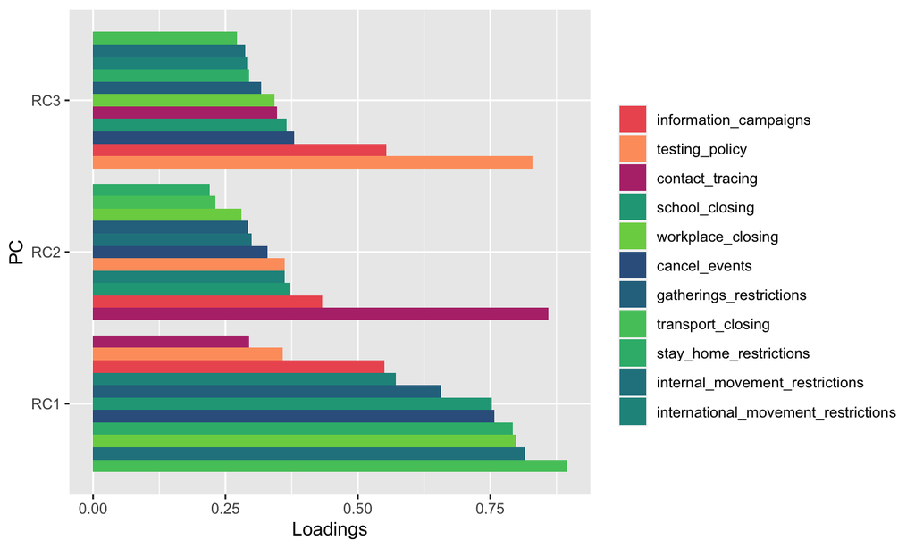

## Resembling patterns

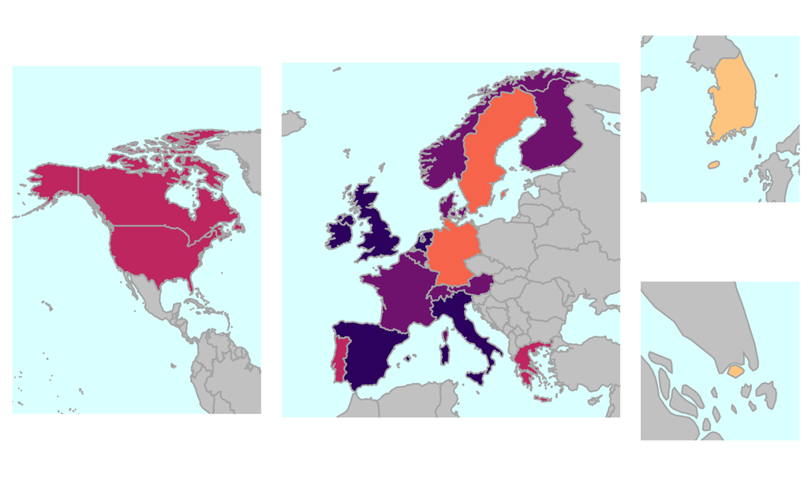

## Resembling patterns

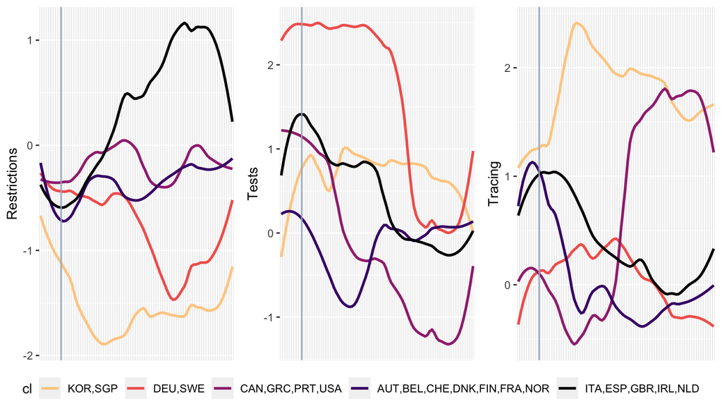